# Mid Term Project

Shyni David

5/17/2019

Library

```r
library(tidyverse)
 library(readr)
#install.packages("sqldf")
library(sqldf)
library(caret)
library(glmnet)
library(caTools)  ##for ROC

setwd("~/Desktop/FISHER SMB-A/Term 5/Macro Marketing/MIDTERM PROJECT")
```

Import

```r
Abandoned_Data_Seed <- read_csv("Abandoned_Data_Seed.csv")
Reservation_Data_Seed <- read_csv("Reservation_Data_Seed.csv")
```

### I. The Business Problem

ABD contains data for all the customers in the dataset that were already pursued (advertised) but ended up not buying a vacation package.

#### Business Problem: Should we retarget those customers?

Q1: In light of your experience as a business woman/man, argue why this is a sensible business question.

Ans. Most of the time a majority of first time visitors are not ready to purchase. So there is a need to encourage the visitors to return more often to the site. Retargeting is the best way to target the first time visitors. It helps to target existing prospects and reduces the effort in acquiring new ones. And this makes the overall marketing campaign cheaper and cost effective.

An experiment is run, where customers in the abandoned dataset are randomly placed in a treatment or in a control group (see column L in both files).Those marked as “test” are retargeted (treated), the others marked as control are part of the control group.

Q2: compute the summary statistics (mean, median, q5, q95, standard deviation) of the Test_variable: a dummy with a value of 1 if tested 0 if control in the ABD database.

```r
#unique identifier
AD <- Abandoned_Data_Seed %>% mutate(UniqueKey = row_number())
RS <- Reservation_Data_Seed  %>% mutate(UniqueKey = row_number())

Abandoned_Data_Seed_01 <- AD %>%
              mutate(Test = ifelse(Test_Control == "test", 1, ifelse(Test_Control == "control", 0, 9)))

 Reservation_Data_Seed_01 <-RS  %>%
              mutate(Test = ifelse(Test_Control == "test", 1, ifelse(Test_Control == "control", 0, 9)))

 #Table for Test
table(Abandoned_Data_Seed_01$Test)
```

```
##
##    0    1
## 4176 4266
```

```r
#Proportion for Test
tab1 <- table(Abandoned_Data_Seed_01$Test)
prop.table(tab1)
```

```
##
##         0         1
## 0.4946695 0.5053305
```

```r
#summary - 1st Qu= q5, 3rd Qu. = q95, Median
  summary(Abandoned_Data_Seed_01$Test)
```

```
##    Min. 1st Qu.  Median    Mean 3rd Qu.    Max.
##  0.0000  0.0000  1.0000  0.5053  1.0000  1.0000
```

```r
#mean
p.est <- mean(Abandoned_Data_Seed_01$Test)
p.est
```

```
## [1] 0.5053305
```

```r
#Standard deviation
variance <- (p.est*(1-p.est))/nrow(Abandoned_Data_Seed_01$Test)
variance
```

```
## numeric(0)
```

```r
std.dev <- sqrt(variance)

std.dev
```

```
## numeric(0)
```

Q3: compute the same summary statistics for this Test_variable by blocking on States, wherever this information is available.

```r
 Abandoned_Data_Seed_02 <- Abandoned_Data_Seed_01 %>%
              mutate(HasState = ifelse(Address !=  "", 1, ifelse(Address = "", 0, ifelse(is.na(Address) == TRUE, 0,0))))

Reservation_Data_Seed_02 <- Reservation_Data_Seed_01 %>%
              mutate(HasState = ifelse(Address !=  "", 1, ifelse(Address = "", 0, ifelse(is.na(Address) == TRUE, 0,0))))

#summary - 1st Qu= q5, 3rd Qu. = q95, Median
  summary(Abandoned_Data_Seed_02$HasState[Abandoned_Data_Seed_02$HasState == 1])
```

```
##    Min. 1st Qu.  Median    Mean 3rd Qu.    Max.    NA's
##       1       1       1       1       1       1    4630
```

```r
#Standard deviation
variance <- (p.est*(1-p.est))/nrow(Abandoned_Data_Seed_02$Test)
variance
```

```
## numeric(0)
```

```r
std.dev <- sqrt(variance)
std.dev
```

```
## numeric(0)
```

Q4: In light of the summaries in Q3, Q4 does the experiment appear to be executed properly? Any imbalance in the assignments to treatment and control when switching to the State level? What would you have done differently?

### II. Data Matching

Q5: Argue that for proper causal inference based on experiments this is potentially problematic: “We do not observe some “outcomes” for some customers”. Argue that, however, matching appropriately the ABD with the RS dataset can back out this information.

Analysing the data

```r
RA_00 <- sqldf("select * from Abandoned_Data_Seed where Caller_ID in (select caller_id from Reservation_Data_Seed)")
#There are no match with Caller_ID
#--------------

# Joining First and Last Name as Customer Name
Abandoned_Data_Seed_03 <- Abandoned_Data_Seed_02 %>% unite("Customer", c("First_Name", "Last_Name"), sep = " ", remove = FALSE)

Reservation_Data_Seed_03 <- Reservation_Data_Seed_02 %>% unite("Customer", c("First_Name", "Last_Name"), sep = " ", remove = FALSE)

#Joining  RS and ABD files with Customer
RA_01 <- sqldf("select * from Abandoned_Data_Seed_03 where Customer in (select Customer from Reservation_Data_Seed_03)")
glimpse(RA_01)
```

```
## Observations: 996
## Variables: 16
## $ Caller_ID      <chr> "83119994SISMLSRO", "56735219WLNASIKD", "27995245…
## $ Session        <chr> "2014.01.06 04:15:43", "2014.01.06 05:32:05", "20…
## $ Customer       <chr> "Kyle NA", "Jadyn NA", "Winona NA", "Ewald NA", "…
## $ First_Name     <chr> "Kyle", "Jadyn", "Winona", "Ewald", "Weldon", "Ja…
## $ Last_Name      <chr> NA, NA, NA, NA, NA, NA, NA, NA, NA, NA, NA, NA, N…
## $ Street         <chr> NA, NA, NA, NA, NA, NA, NA, NA, NA, NA, NA, NA, N…
## $ City           <chr> NA, NA, NA, NA, NA, NA, NA, NA, NA, NA, NA, NA, N…
## $ Address        <chr> NA, NA, "AK", "CT", "NJ", NA, NA, NA, NA, NA, "WY…
## $ Zipcode        <chr> NA, NA, NA, NA, NA, NA, NA, NA, NA, NA, NA, NA, N…
## $ Email          <chr> NA, NA, NA, NA, NA, NA, NA, NA, NA, NA, NA, NA, N…
## $ Incoming_Phone <chr> "(703)-220-0148", "(713)-652-3296", "(309)-442-83…
## $ Contact_Phone  <chr> "(703)-220-0148", "(713)-652-3296", "(309)-442-83…
## $ Test_Control   <chr> "control", "control", "test", "test", "control", …
## $ UniqueKey      <int> 2, 18, 28, 29, 42, 47, 50, 62, 75, 78, 83, 84, 86…
## $ Test           <dbl> 0, 0, 1, 1, 0, 0, 1, 1, 0, 1, 1, 1, 0, 1, 0, 0, 0…
## $ HasState       <dbl> NA, NA, 1, 1, 1, NA, NA, NA, NA, NA, 1, NA, NA, 1…
```

```r
#-----------------------------------------

# #Joining  RS and ABD files with Customer and email id
#Joining  RS and ABD files with Customer
RA_02 <- sqldf("select * from Abandoned_Data_Seed_03 where Customer in (select Customer from Reservation_Data_Seed_03) and email in (select email from Reservation_Data_Seed_03) ")
glimpse(RA_02)
```

```
## Observations: 0
## Variables: 16
## $ Caller_ID      <chr>
## $ Session        <chr>
## $ Customer       <chr>
## $ First_Name     <chr>
## $ Last_Name      <chr>
## $ Street         <chr>
## $ City           <chr>
## $ Address        <chr>
## $ Zipcode        <chr>
## $ Email          <chr>
## $ Incoming_Phone <chr>
## $ Contact_Phone  <chr>
## $ Test_Control   <chr>
## $ UniqueKey      <int>
## $ Test           <dbl>
## $ HasState       <dbl>
```

```r
#________________________________________

# in ABD Joining Street, City, Address, Zip code as Complete_Address
Abandoned_Data_Seed_04 <- Abandoned_Data_Seed_03 %>% unite("Complete_Address", c("Street", "City", "Address", "Zipcode"), sep = " ", remove = FALSE)

 # in ABD Joining Customer , Complete_Address
Abandoned_Data_Seed_05 <- Abandoned_Data_Seed_04 %>% unite("Search_Customer", c( "Customer", "Complete_Address"), sep = " ", remove = FALSE)
#--
# in RS Joining Street, City, Address, Zip code as Complete_Address
Reservation_Data_Seed_04 <- Reservation_Data_Seed_03 %>% unite("Complete_Address", c("Street", "City", "Address", "Zipcode"), sep = " ", remove = FALSE)

 # in RS Joining Customer , Complete_Address
Reservation_Data_Seed_05 <- Reservation_Data_Seed_04 %>% unite("Search_Customer", c( "Customer", "Complete_Address"), sep = " ", remove = FALSE)
#--
#Joining RS and ABD files with Search_Customer(Customer + complete address)
RA_03 <- sqldf("select * from Abandoned_Data_Seed_05 where Search_Customer in (select Search_Customer from Reservation_Data_Seed_05 )")
glimpse(RA_03)
```

```
## Observations: 215
## Variables: 18
## $ Caller_ID        <chr> "83119994SISMLSRO", "51474754NRFMTRQK", "605182…
## $ Session          <chr> "2014.01.06 04:15:43", "2014.01.06 12:56:01", "…
## $ Search_Customer  <chr> "Kyle NA NA NA NA NA", "Cecelia NA NA NA NA NA"…
## $ Customer         <chr> "Kyle NA", "Cecelia NA", "Reese NA", "Marguerit…
## $ First_Name       <chr> "Kyle", "Cecelia", "Reese", "Marguerite", "Ewal…
## $ Last_Name        <chr> NA, NA, NA, NA, NA, NA, NA, NA, NA, NA, NA, NA,…
## $ Complete_Address <chr> "NA NA NA NA", "NA NA NA NA", "NA NA NA NA", "N…
## $ Street           <chr> NA, NA, NA, NA, NA, NA, NA, NA, NA, NA, NA, NA,…
## $ City             <chr> NA, NA, NA, NA, NA, NA, NA, NA, NA, NA, NA, NA,…
## $ Address          <chr> NA, NA, NA, NA, NA, NA, NA, NA, NA, NA, NA, NA,…
## $ Zipcode          <chr> NA, NA, NA, NA, NA, NA, NA, NA, NA, NA, NA, NA,…
## $ Email            <chr> NA, NA, NA, NA, NA, NA, NA, NA, NA, NA, NA, NA,…
## $ Incoming_Phone   <chr> "(703)-220-0148", "(260)-635-6010", "(573)-847-…
## $ Contact_Phone    <chr> "(703)-220-0148", "(260)-635-6010", "(573)-847-…
## $ Test_Control     <chr> "control", "control", "control", "test", "test"…
## $ UniqueKey        <int> 2, 106, 127, 151, 174, 183, 316, 375, 382, 413,…
## $ Test             <dbl> 0, 0, 0, 1, 1, 0, 0, 1, 0, 0, 1, 1, 0, 0, 1, 1,…
## $ HasState         <dbl> NA, NA, NA, NA, NA, NA, NA, NA, NA, NA, NA, NA,…
```

```r
#------------------------
#Joining RS and ABD with Email address and phone number
RA_04 <- sqldf("select * from Abandoned_Data_Seed_05 where Email in (select Email  from Reservation_Data_Seed_05 ) and ((incoming_phone in (select incoming_phone from Reservation_Data_Seed_05)) or (contact_phone in(select contact_phone from Reservation_Data_Seed_05))) ")
glimpse(RA_04)
```

```
## Observations: 61
## Variables: 18
## $ Caller_ID        <chr> "29788310DXSYOYWT", "02097717MEMMKLLQ", "676400…
## $ Session          <chr> "2014.01.07 09:40:59", "2014.01.07 16:24:07", "…
## $ Search_Customer  <chr> "Sincere Denesik NA NA OR 75963-5199", "Bradly …
## $ Customer         <chr> "Sincere Denesik", "Bradly Little", "Janice Kre…
## $ First_Name       <chr> "Sincere", "Bradly", "Janice", "Lucile", "Guill…
## $ Last_Name        <chr> "Denesik", "Little", "Kreiger", "Wilkinson", "M…
## $ Complete_Address <chr> "NA NA OR 75963-5199", "NA NA NE NA", "NA NA NJ…
## $ Street           <chr> NA, NA, NA, NA, NA, "611 Dietrich Plains", NA, …
## $ City             <chr> NA, NA, NA, NA, NA, "North Dixiebury", NA, NA, …
## $ Address          <chr> "OR", "NE", "NJ", "NJ", "WV", "ND", "NE", "SC",…
## $ Zipcode          <chr> "75963-5199", NA, NA, NA, "96630-9481", "61906-…
## $ Email            <chr> "paulobi444@gmail.com", "antifraudefcc_ng@aol.i…
## $ Incoming_Phone   <chr> "(615)-690-7091", "(321)-492-4457", "(410)-262-…
## $ Contact_Phone    <chr> "(615)-690-7091", "(321)-492-4457", "(410)-262-…
## $ Test_Control     <chr> "test", "test", "test", "test", "test", "contro…
## $ UniqueKey        <int> 357, 439, 496, 649, 661, 670, 681, 912, 948, 97…
## $ Test             <dbl> 1, 1, 1, 1, 1, 0, 1, 1, 1, 1, 0, 1, 1, 1, 1, 1,…
## $ HasState         <dbl> 1, 1, 1, 1, 1, 1, 1, 1, 1, 1, NA, 1, 1, NA, 1, …
```

```r
RA_044 <- sqldf("select * from Abandoned_Data_Seed_05 where Email in (select Email  from Reservation_Data_Seed_05 ) ")
glimpse(RA_044)
```

```
## Observations: 75
## Variables: 18
## $ Caller_ID        <chr> "29788310DXSYOYWT", "47678843KOIPKWGW", "020977…
## $ Session          <chr> "2014.01.07 09:40:59", "2014.01.07 10:52:05", "…
## $ Search_Customer  <chr> "Sincere Denesik NA NA OR 75963-5199", "Giovani…
## $ Customer         <chr> "Sincere Denesik", "Giovani Gerlach", "Bradly L…
## $ First_Name       <chr> "Sincere", "Giovani", "Bradly", "Ken", "Janice"…
## $ Last_Name        <chr> "Denesik", "Gerlach", "Little", "Bartell", "Kre…
## $ Complete_Address <chr> "NA NA OR 75963-5199", "NA NA HI NA", "NA NA NE…
## $ Street           <chr> NA, NA, NA, NA, NA, NA, NA, "611 Dietrich Plain…
## $ City             <chr> NA, NA, NA, NA, NA, NA, NA, "North Dixiebury", …
## $ Address          <chr> "OR", "HI", "NE", "VT", "NJ", "NJ", "WV", "ND",…
## $ Zipcode          <chr> "75963-5199", NA, NA, NA, NA, NA, "96630-9481",…
## $ Email            <chr> "paulobi444@gmail.com", "cynthia_david1010@yaho…
## $ Incoming_Phone   <chr> "(615)-690-7091", "(657)-138-1874", "(321)-492-…
## $ Contact_Phone    <chr> "(615)-690-7091", NA, "(321)-492-4457", "(734)-…
## $ Test_Control     <chr> "test", "control", "test", "test", "test", "tes…
## $ UniqueKey        <int> 357, 370, 439, 473, 496, 649, 661, 670, 681, 91…
## $ Test             <dbl> 1, 0, 1, 1, 1, 1, 1, 0, 1, 1, 1, 1, 1, 0, 1, 1,…
## $ HasState         <dbl> 1, 1, 1, 1, 1, 1, 1, 1, 1, 1, 1, 1, 1, NA, 1, 1…
```

```r
#--------------------------
#Checking uniqueness with  Contact  Phone numbers
Abandoned_Data_Seed_05_01 <- Abandoned_Data_Seed_05 %>%
  select(Search_Customer, Email, Contact_Phone)
unique(Abandoned_Data_Seed_05_01)
```

```
## # A tibble: 8,442 x 3
##    Search_Customer                  Email Contact_Phone
##    <chr>                            <chr> <chr>
##  1 Bertha NA NA NA NA NA            <NA>  (864)-004-6354
##  2 Kyle NA NA NA NA NA              <NA>  (703)-220-0148
##  3 Paxton NA NA NA NA NA            <NA>  (559)-299-7745
##  4 Thelma NA NA NA NA NA            <NA>  (636)-611-4439
##  5 Lorna NA NA NA NA NA             <NA>  (253)-461-5118
##  6 Leann NA NA NA NA NA             <NA>  (407)-910-9280
##  7 Jackson Lueilwitz NA NA NA NA    <NA>  (803)-853-6182
##  8 Hector Dickens NA NA NE NA       <NA>  (631)-808-0736
##  9 Nayeli Green NA NA NA NA         <NA>  (918)-738-2706
## 10 Joey Denesik NA East Jarod UT NA <NA>  (440)-480-7247
## # … with 8,432 more rows
```

```r
#Joining RS and ABD with Contact phone number
RA_05 <- sqldf("select * from Abandoned_Data_Seed_05 where Contact_phone  in (select contact_phone   from Reservation_Data_Seed_05 )")
glimpse(RA_05)
```

```
## Observations: 185
## Variables: 18
## $ Caller_ID        <chr> "03241649AHZKPWYH", "83559451LHCUAFYT", "180865…
## $ Session          <chr> "2014.01.06 05:11:21", "2014.01.06 19:15:05", "…
## $ Search_Customer  <chr> "Johnny Wilderman NA NA NY 18715", "Lionel NA N…
## $ Customer         <chr> "Johnny Wilderman", "Lionel NA", "Abbey NA", "N…
## $ First_Name       <chr> "Johnny", "Lionel", "Abbey", "Nicola", "Frederi…
## $ Last_Name        <chr> "Wilderman", NA, NA, NA, NA, "Turcotte", NA, NA…
## $ Complete_Address <chr> "NA NA NY 18715", "NA NA NA NA", "NA NA AL NA",…
## $ Street           <chr> NA, NA, NA, NA, NA, NA, NA, NA, NA, NA, NA, NA,…
## $ City             <chr> NA, NA, NA, NA, NA, NA, NA, NA, NA, NA, NA, NA,…
## $ Address          <chr> "NY", NA, "AL", NA, "NH", NA, NA, "UT", NA, "VT…
## $ Zipcode          <chr> "18715", NA, NA, NA, NA, NA, NA, NA, NA, NA, NA…
## $ Email            <chr> NA, NA, NA, NA, NA, NA, NA, NA, NA, NA, NA, NA,…
## $ Incoming_Phone   <chr> "(757)-759-5303", "(703)-986-0864", "(830)-998-…
## $ Contact_Phone    <chr> "(510)-985-8923", "(518)-375-2652", "(830)-998-…
## $ Test_Control     <chr> "test", "test", "test", "test", "test", "test",…
## $ UniqueKey        <int> 14, 184, 185, 190, 206, 228, 265, 267, 318, 363…
## $ Test             <dbl> 1, 1, 1, 1, 1, 1, 1, 0, 1, 1, 0, 1, 1, 1, 1, 1,…
## $ HasState         <dbl> 1, NA, 1, NA, 1, NA, NA, 1, NA, 1, 1, 1, 1, 1, …
```

```r
#------------------------
#Checking uniqueness with  Incoming  Phone numbers
Abandoned_Data_Seed_05_02 <- Abandoned_Data_Seed_05 %>%
  select(Search_Customer, Email, Incoming_Phone )
unique(Abandoned_Data_Seed_05_02) #  47 customers had same incoming but different                                   #contact phone
```

```
## # A tibble: 8,395 x 3
##    Search_Customer                  Email Incoming_Phone
##    <chr>                            <chr> <chr>
##  1 Bertha NA NA NA NA NA            <NA>  (864)-004-6354
##  2 Kyle NA NA NA NA NA              <NA>  (703)-220-0148
##  3 Paxton NA NA NA NA NA            <NA>  (559)-299-7745
##  4 Thelma NA NA NA NA NA            <NA>  (636)-611-4439
##  5 Lorna NA NA NA NA NA             <NA>  (253)-461-5118
##  6 Leann NA NA NA NA NA             <NA>  (407)-910-9280
##  7 Jackson Lueilwitz NA NA NA NA    <NA>  (803)-853-6182
##  8 Hector Dickens NA NA NE NA       <NA>  (631)-808-0736
##  9 Nayeli Green NA NA NA NA         <NA>  (918)-738-2706
## 10 Joey Denesik NA East Jarod UT NA <NA>  (440)-480-7247
## # … with 8,385 more rows
```

```r
#Joining RS and ABD with Incoming  phone number and Customer(first and last name)
RA_06 <- sqldf("select * from Abandoned_Data_Seed_05 where Incoming_phone in (select Incoming_phone   from Reservation_Data_Seed_05 ) and customer in (select customer  from Reservation_Data_Seed_05)")
glimpse(RA_06)
```

```
## Observations: 17
## Variables: 18
## $ Caller_ID        <chr> "85080592TEFIPACV", "05334034DMHRGBJP", "991318…
## $ Session          <chr> "2014.01.06 11:25:41", "2014.01.06 21:10:53", "…
## $ Search_Customer  <chr> "Lesly NA NA NA IA NA", "Frederik NA NA NA NH N…
## $ Customer         <chr> "Lesly NA", "Frederik NA", "Jedidiah NA", "Cade…
## $ First_Name       <chr> "Lesly", "Frederik", "Jedidiah", "Caden", "Dela…
## $ Last_Name        <chr> NA, NA, NA, NA, NA, NA, NA, NA, NA, NA, NA, NA,…
## $ Complete_Address <chr> "NA NA IA NA", "NA NA NH NA", "NA NA UT NA", "N…
## $ Street           <chr> NA, NA, NA, NA, NA, NA, NA, NA, NA, NA, NA, NA,…
## $ City             <chr> NA, NA, NA, NA, NA, NA, NA, NA, NA, NA, NA, NA,…
## $ Address          <chr> "IA", "NH", "UT", NA, NA, NA, NA, NA, NA, NA, N…
## $ Zipcode          <chr> NA, NA, NA, NA, NA, NA, NA, NA, NA, NA, NA, NA,…
## $ Email            <chr> NA, NA, NA, NA, NA, NA, NA, NA, NA, NA, NA, NA,…
## $ Incoming_Phone   <chr> "(402)-153-4684", "(248)-549-8764", "(878)-091-…
## $ Contact_Phone    <chr> "(619)-074-3663", "(248)-549-8764", "(878)-091-…
## $ Test_Control     <chr> "test", "test", "control", "test", "test", "con…
## $ UniqueKey        <int> 88, 206, 267, 1289, 1412, 1800, 1958, 2106, 273…
## $ Test             <dbl> 1, 1, 0, 1, 1, 0, 1, 0, 0, 1, 1, 1, 1, 1, 1, 0,…
## $ HasState         <dbl> 1, 1, 1, NA, NA, NA, NA, NA, NA, NA, NA, NA, NA…
```

```r
#----------
#Joining RS and ABD with Incoming  phone number and Last name
RA_07 <- sqldf("select * from Abandoned_Data_Seed_05 where Incoming_phone in (select Incoming_phone   from Reservation_Data_Seed_05 ) and last_name in (select last_name  from Reservation_Data_Seed_05)")
glimpse(RA_07)
```

```
## Observations: 137
## Variables: 18
## $ Caller_ID        <chr> "36854393GIZMEDRD", "29788310DXSYOYWT", "924868…
## $ Session          <chr> "2014.01.06 20:31:53", "2014.01.07 09:40:59", "…
## $ Search_Customer  <chr> "Therese Harber NA NA KS NA", "Sincere Denesik …
## $ Customer         <chr> "Therese Harber", "Sincere Denesik", "Meghan Mo…
## $ First_Name       <chr> "Therese", "Sincere", "Meghan", "Bradly", "Casp…
## $ Last_Name        <chr> "Harber", "Denesik", "Monahan", "Little", "Gold…
## $ Complete_Address <chr> "NA NA KS NA", "NA NA OR 75963-5199", "NA NA VT…
## $ Street           <chr> NA, NA, NA, NA, NA, NA, NA, NA, NA, NA, NA, "61…
## $ City             <chr> NA, NA, NA, NA, NA, NA, NA, NA, NA, NA, NA, "No…
## $ Address          <chr> "KS", "OR", "VT", "NE", NA, "MS", "NJ", NA, "NJ…
## $ Zipcode          <chr> NA, "75963-5199", NA, NA, NA, "68981-0820", NA,…
## $ Email            <chr> "jerryhassan@hotmail.com", "paulobi444@gmail.co…
## $ Incoming_Phone   <chr> "(814)-861-7221", "(615)-690-7091", "(785)-484-…
## $ Contact_Phone    <chr> "(814)-861-7221", "(615)-690-7091", "(785)-484-…
## $ Test_Control     <chr> "test", "test", "test", "test", "test", "test",…
## $ UniqueKey        <int> 199, 357, 363, 439, 449, 451, 496, 503, 649, 65…
## $ Test             <dbl> 1, 1, 1, 1, 1, 1, 1, 1, 1, 1, 1, 0, 1, 1, 1, 1,…
## $ HasState         <dbl> 1, 1, 1, 1, NA, 1, 1, NA, 1, NA, 1, 1, 1, 1, 1,…
```

```r
#-------------------
#Joining RS and ABD with first name , last name and zip
Abandoned_Data_Seed_06 <- Abandoned_Data_Seed_05 %>% unite("Namezip", c( "Customer", "Zipcode"), sep = " ", remove = FALSE)

Reservation_Data_Seed_06 <- Reservation_Data_Seed_05 %>% unite("Namezip", c( "Customer", "Zipcode"), sep = " ", remove = FALSE)


RA_08 <- sqldf("select * from Abandoned_Data_Seed_06 where namezip in (select namezip  from Reservation_Data_Seed_06 ) ")
glimpse(RA_08)
```

```
## Observations: 748
## Variables: 19
## $ Caller_ID        <chr> "83119994SISMLSRO", "56735219WLNASIKD", "279952…
## $ Session          <chr> "2014.01.06 04:15:43", "2014.01.06 05:32:05", "…
## $ Search_Customer  <chr> "Kyle NA NA NA NA NA", "Jadyn NA NA NA NA NA", …
## $ Namezip          <chr> "Kyle NA NA", "Jadyn NA NA", "Winona NA NA", "E…
## $ Customer         <chr> "Kyle NA", "Jadyn NA", "Winona NA", "Ewald NA",…
## $ First_Name       <chr> "Kyle", "Jadyn", "Winona", "Ewald", "Weldon", "…
## $ Last_Name        <chr> NA, NA, NA, NA, NA, NA, NA, NA, NA, NA, NA, NA,…
## $ Complete_Address <chr> "NA NA NA NA", "NA NA NA NA", "NA NA AK NA", "N…
## $ Street           <chr> NA, NA, NA, NA, NA, NA, NA, NA, NA, NA, NA, NA,…
## $ City             <chr> NA, NA, NA, NA, NA, NA, NA, NA, NA, NA, NA, NA,…
## $ Address          <chr> NA, NA, "AK", "CT", "NJ", NA, NA, NA, "WY", NA,…
## $ Zipcode          <chr> NA, NA, NA, NA, NA, NA, NA, NA, NA, NA, NA, NA,…
## $ Email            <chr> NA, NA, NA, NA, NA, NA, NA, NA, NA, NA, NA, NA,…
## $ Incoming_Phone   <chr> "(703)-220-0148", "(713)-652-3296", "(309)-442-…
## $ Contact_Phone    <chr> "(703)-220-0148", "(713)-652-3296", "(309)-442-…
## $ Test_Control     <chr> "control", "control", "test", "test", "control"…
## $ UniqueKey        <int> 2, 18, 28, 29, 42, 47, 75, 78, 83, 86, 88, 101,…
## $ Test             <dbl> 0, 0, 1, 1, 0, 0, 0, 1, 1, 0, 1, 0, 0, 0, 1, 0,…
## $ HasState         <dbl> NA, NA, 1, 1, 1, NA, NA, NA, 1, NA, 1, NA, 1, N…
```

```r
# in ABD Joining Incoming Phone + Customer(First and Last name)
Abandoned_Data_Seed_07 <- Abandoned_Data_Seed_06 %>% unite("CustIncPh", c("Customer", "Incoming_Phone"), sep = " ", remove = FALSE)
Reservation_Data_Seed_07 <- Reservation_Data_Seed_06 %>% unite("CustIncPh", c("Customer", "Incoming_Phone"), sep = " ", remove = FALSE)

# in ABD Joining Incoming Phone +  Last name)
Abandoned_Data_Seed_08 <- Abandoned_Data_Seed_07 %>% unite("LastNameIncPh", c("Last_Name", "Incoming_Phone"), sep = " ", remove = FALSE)
Reservation_Data_Seed_08 <- Reservation_Data_Seed_07 %>% unite("LastNameIncPh", c("Customer", "Incoming_Phone"), sep = " ", remove = FALSE)

# in ABD Joining Incoming Phone +  First name+ Last name (Customer) , Zipcode)
Abandoned_Data_Seed_09 <- Abandoned_Data_Seed_08 %>% unite("CustZip", c("Customer", "Zipcode"), sep = " ", remove = FALSE)
Reservation_Data_Seed_09 <- Reservation_Data_Seed_08 %>% unite("CustZip", c("Customer", "Zipcode"), sep = " ", remove = FALSE)


#Fill in NA for blank values
Abandoned_Data_Seed_09[Abandoned_Data_Seed_09 == ""] <- NA
Reservation_Data_Seed_09[Reservation_Data_Seed_09 == ""] <- NA
```

Caller ID is a unique number and cannot be compared between ABD and RS. So to match the datasets a combination of variables has to be identified and matched in both the data sets. Attributes like first name, last name, email id, zipcode, Contact and Incoming phone numbers are missing in the dataset, hence it cannot be used as the only way to determine the match with Reservation file. So in order to match the datasets correctly some key attributes about the customers has to be identified and matched in both data sets.  
If we match by Caller ID, there is no match - RA_00  
If we match by first name and last name (RA_01) -996 records  
If we match first name, last name and email id there are 0 matches(RA_02)  
If match by first name, last name , complete address -215 records RA_03  
RA_044 - Match with email address -75 records  
RA_04 - Match with email address and (contact phone or incoming phone) - 61 records  
RA_05 - Match with contact phone 185 records  
RA_06- incoming ph and first and last name - 17 records  
RA_07 incoming phone and last name - 137 records  
RA_08 -first name last name and zip - 748 records

Q6: After observing the data in the both files, argue that customers can be matched across some “data keys” (columns labels). Properly identify all these data keys (feel free to add a few clarifying examples if needed)

As many options tried above as in Q5., some of the following keys can be used to uniquely identify in both data sets:  
- email  
-contact phone (as this is given by the customer)  
-incoming phone and last name - this is the phone number the customer used to call in so linking by last name. Since joining by first name, last name and incoming phone had very less matching records. -first name, last name and zip code

So I am selecting the keys based on analysis and with higher matching records.

Q7: EXTREMELY CAREFULLY DESCRIBE YOUR DATA MATCHING PROCEDURE IN ORDER TO IDENTIFY: (1) Customers in the TREATMENT group who bought  
(2) Customers in the TREATMENT group who did not buy  
(3) Customers in the Control group who bought, and  
(4) Customers in the Control group who did not buy. Be as precise as possible.

```r
#Matching RS and ABD by  email
ABD_Email <-  ifelse(!is.na(Abandoned_Data_Seed_09$Email),Abandoned_Data_Seed_09$Email %in% Reservation_Data_Seed_09$Email,FALSE)


#Matching RS and ABD by contact# as this is given by Customer
ABD_ContactPhone <-   ifelse(!is.na(Abandoned_Data_Seed_09$Contact_Phone),Abandoned_Data_Seed_09$Contact_Phone %in% Reservation_Data_Seed_09$Contact_Phone,FALSE)



#Matching RS and ABD by last name and Incoming phone
ABD_LastName_IncomingPhone  <- ifelse(!is.na(Abandoned_Data_Seed_09$Last_Name) & !is.na(Abandoned_Data_Seed_09$Incoming_Phone),paste0(Abandoned_Data_Seed_09$Last_Name,Abandoned_Data_Seed_09$Incoming_Phone) %in% paste0(Reservation_Data_Seed_09$Last_Name,Reservation_Data_Seed_09$Incoming_Phone),FALSE)


#Matching  RS and ABD files with  Customer(first name, last name) + zip code
 ABD_Name_Zipcode <- ifelse((!is.na(Abandoned_Data_Seed_09$First_Name) & !is.na(Abandoned_Data_Seed_09$Last_Name)) & !is.na(Abandoned_Data_Seed_09$Zipcode) ,paste0(Abandoned_Data_Seed_09$First_Name,Abandoned_Data_Seed_09$Last_Name,Abandoned_Data_Seed_09$Zipcode) %in% paste0(Reservation_Data_Seed_09$First_Name,Reservation_Data_Seed_09$Last_Name,Reservation_Data_Seed_09$Zipcode),FALSE)



 #Combine all the matches
All_Matches_ABD <-  ABD_Email  | ABD_ContactPhone  | ABD_LastName_IncomingPhone |  ABD_Name_Zipcode
ABD_matches <- Abandoned_Data_Seed_09[All_Matches_ABD,]


 #Remove duplicates
 ABD_matches <- ABD_matches[!duplicated(ABD_matches[,c("Contact_Phone")]), ]


ABD_IncPh_dup <- duplicated(ABD_matches[,c("Incoming_Phone")])
ABD_LastName_dup <- duplicated(ABD_matches[,c("Last_Name")])
ABD_FirstName_dup <- duplicated(ABD_matches[,c("First_Name")])
ABD_Zipcode_dup <- duplicated(ABD_matches[,c("Zipcode")])


ABD_matches <- ABD_matches[!(ABD_IncPh_dup & ABD_LastName_dup),]
ABD_matches <- ABD_matches[!(ABD_FirstName_dup & ABD_LastName_dup  & ABD_Zipcode_dup),]

ABD_matches_01 <- unique(ABD_matches)
glimpse(ABD_matches_01)
```

```
## Observations: 192
## Variables: 22
## $ Caller_ID        <chr> "03241649AHZKPWYH", "83559451LHCUAFYT", "180865…
## $ Session          <chr> "2014.01.06 05:11:21", "2014.01.06 19:15:05", "…
## $ Search_Customer  <chr> "Johnny Wilderman NA NA NY 18715", "Lionel NA N…
## $ Namezip          <chr> "Johnny Wilderman 18715", "Lionel NA NA", "Abbe…
## $ CustIncPh        <chr> "Johnny Wilderman (757)-759-5303", "Lionel NA (…
## $ CustZip          <chr> "Johnny Wilderman 18715", "Lionel NA NA", "Abbe…
## $ Customer         <chr> "Johnny Wilderman", "Lionel NA", "Abbey NA", "N…
## $ First_Name       <chr> "Johnny", "Lionel", "Abbey", "Nicola", "Frederi…
## $ LastNameIncPh    <chr> "Wilderman (757)-759-5303", "NA (703)-986-0864"…
## $ Last_Name        <chr> "Wilderman", NA, NA, NA, NA, "Turcotte", NA, NA…
## $ Complete_Address <chr> "NA NA NY 18715", "NA NA NA NA", "NA NA AL NA",…
## $ Street           <chr> NA, NA, NA, NA, NA, NA, NA, NA, NA, NA, NA, NA,…
## $ City             <chr> NA, NA, NA, NA, NA, NA, NA, NA, NA, NA, NA, NA,…
## $ Address          <chr> "NY", NA, "AL", NA, "NH", NA, NA, "UT", NA, "OR…
## $ Zipcode          <chr> "18715", NA, NA, NA, NA, NA, NA, NA, NA, "75963…
## $ Email            <chr> NA, NA, NA, NA, NA, NA, NA, NA, NA, "paulobi444…
## $ Incoming_Phone   <chr> "(757)-759-5303", "(703)-986-0864", "(830)-998-…
## $ Contact_Phone    <chr> "(510)-985-8923", "(518)-375-2652", "(830)-998-…
## $ Test_Control     <chr> "test", "test", "test", "test", "test", "test",…
## $ UniqueKey        <int> 14, 184, 185, 190, 206, 228, 265, 267, 318, 357…
## $ Test             <dbl> 1, 1, 1, 1, 1, 1, 1, 0, 1, 1, 1, 0, 1, 0, 1, 1,…
## $ HasState         <dbl> 1, NA, 1, NA, 1, NA, NA, 1, NA, 1, 1, 1, 1, 1, …
```

```r
#Customer in Abandoned file found in Reservation file marked as 1 else marked as 0
Abandoned_Data_Seed_10 <- Abandoned_Data_Seed_09 %>% mutate(MatchRS = 0)

Abandoned_Data_Seed_10$MatchRS <- ifelse((Abandoned_Data_Seed_10$UniqueKey  %in% ABD_matches$UniqueKey) == TRUE, 1, 0)
```

Q8: Are there problematic cases? i.e. data records not matchable? If so, provide a few examples and toss those cases out of the analysis.

I had to focus on the uniqueness of a field and then determine combinations to be used as a key. The contact phone number is provoded by the customer so that was used as a key. The email id is unique for the customer and is used as key. Many of the contact address, email, contact phone ,incoming phone and names had NA’s. So matches were made on each key or a combination and then aggregated.

Q9: Complete the following cross-tabulation:  
Group Outcome Buy No Buy  
Treatment Number Number  
Control Number Number

```r
treatments <- nrow(Abandoned_Data_Seed_10[Abandoned_Data_Seed_10$Test == 1,])

controls <- nrow(Abandoned_Data_Seed_10[Abandoned_Data_Seed_10$Test == 0,])

treatment_buy <- length(Abandoned_Data_Seed_10$MatchRS[Abandoned_Data_Seed_10$MatchRS == 1 & Abandoned_Data_Seed_10$Test == 1])

treatment_nobuy <- length(Abandoned_Data_Seed_10$MatchRS[Abandoned_Data_Seed_10$MatchRS == 0 & Abandoned_Data_Seed_10$Test == 1])

control_buy <- length(Abandoned_Data_Seed_10$MatchRS[Abandoned_Data_Seed_10$MatchRS == 1 & Abandoned_Data_Seed_10$Test == 0])


control_nobuy <- length(Abandoned_Data_Seed_10$MatchRS[Abandoned_Data_Seed_10$MatchRS == 0 & Abandoned_Data_Seed_10$Test == 0])

#sqldf("select count(*) from Abandoned_Data_Seed_10 where matchRS = 0 and test = 0")

conv_rate_treatment <- treatment_buy/treatments*100

conv_rate_control <- control_buy/controls*100

cross_tabulation <- data.frame(treatment_buy,treatment_nobuy,control_buy,control_nobuy)

knitr::kable(cross_tabulation)
```

| treatment_buy | treatment_nobuy | control_buy | control_nobuy |
| --- | --- | --- | --- |
| 156 | 4110 | 35 | 4141 |

```r
#Conversion Rate for Treatment group
conv_rate_treatment
```

```
## [1] 3.656821
```

```r
paste0("Conversion Rate for the Treatment Group is ",  round(conv_rate_treatment, 2), "%")
```

```
## [1] "Conversion Rate for the Treatment Group is 3.66%"
```

```r
#Conversion Rate for Control Group
conv_rate_control
```

```
## [1] 0.8381226
```

```r
paste0("Conversion Rate for the Control Group is ",  round(conv_rate_control, 2), "%")
```

```
## [1] "Conversion Rate for the Control Group is 0.84%"
```

We observe that the conversion rate for the Treatment group is higher as expected from the control group. It will be very efficient to retarget the known customers to improve the conversion rate.

Q10: Repeat Q9 for 5 randomly picked states. Report 5 different tables by specifying the states you “randomly picked”.

```r
Abandoned_Data_Seed_10_01 <- Abandoned_Data_Seed_10 %>% group_by(Address) %>% summarize(count = n())
top_n(Abandoned_Data_Seed_10_01, 10)
```

```
## # A tibble: 10 x 2
##    Address count
##    <chr>   <int>
##  1 <NA>     4630
##  2 AR         84
##  3 AZ         98
##  4 CA         85
##  5 IL         84
##  6 NJ         88
##  7 NV         98
##  8 OH         89
##  9 PA         91
## 10 WV         97
```

```r
#AZ
treatment_buy_AZ <- sqldf("select count(*) from Abandoned_Data_Seed_10 where Address = 'AZ' and MatchRS = 1 and Test = 1")


treatment_nobuy_AZ <- sqldf("select count(*) from Abandoned_Data_Seed_10 where Address = 'AZ' and MatchRS = 0 and Test = 1")


control_buy_AZ <- sqldf("select count(*) from Abandoned_Data_Seed_10 where Address = 'AZ' and MatchRS = 1 and Test = 0")


control_nobuy_AZ <-  sqldf("select count(*) from Abandoned_Data_Seed_10 where Address = 'AZ' and MatchRS = 0 and Test = 0")

cross_tabulation_AZ <- data.frame(treatment_buy_AZ,treatment_nobuy_AZ,control_buy_AZ,control_nobuy_AZ)
colnames(cross_tabulation_AZ) <- c("treatment_buy_AZ", "treatment_nobuy_AZ", "control_buy_AZ", "control_nobuy_AZ")

knitr::kable(cross_tabulation_AZ)
```

| treatment_buy_AZ | treatment_nobuy_AZ | control_buy_AZ | control_nobuy_AZ |
| --- | --- | --- | --- |
| 1 | 53 | 1 | 43 |

```r
#NV
treatment_buy_NV <- sqldf("select count(*) from Abandoned_Data_Seed_10 where Address = 'NV' and MatchRS = 1 and Test = 1")


treatment_nobuy_NV <- sqldf("select count(*) from Abandoned_Data_Seed_10 where Address = 'NV' and MatchRS = 0 and Test = 1")


control_buy_NV <- sqldf("select count(*) from Abandoned_Data_Seed_10 where Address = 'NV' and MatchRS = 1 and Test = 0")


control_nobuy_NV <-  sqldf("select count(*) from Abandoned_Data_Seed_10 where Address = 'NV' and MatchRS = 0 and Test = 0")

cross_tabulation_NV <- data.frame(treatment_buy_NV, treatment_nobuy_NV, control_buy_NV, control_nobuy_NV)
colnames(cross_tabulation_NV) <- c("treatment_buy_NV", "treatment_nobuy_NV", "control_buy_NV", "control_nobuy_NV")

knitr::kable(cross_tabulation_NV)
```

| treatment_buy_NV | treatment_nobuy_NV | control_buy_NV | control_nobuy_NV |
| --- | --- | --- | --- |
| 2 | 43 | 0 | 53 |

```r
#OH
treatment_buy_OH <- sqldf("select count(*) from Abandoned_Data_Seed_10 where Address = 'OH' and MatchRS = 1 and Test = 1")


treatment_nobuy_OH <- sqldf("select count(*) from Abandoned_Data_Seed_10 where Address = 'OH' and MatchRS = 0 and Test = 1")


control_buy_OH <- sqldf("select count(*) from Abandoned_Data_Seed_10 where Address = 'OH' and MatchRS = 1 and Test = 0")



control_nobuy_OH <-  sqldf("select count(*) from Abandoned_Data_Seed_10 where Address = 'OH' and MatchRS = 0 and Test = 0")

cross_tabulation_OH <- data.frame(treatment_buy_OH, treatment_nobuy_OH, control_buy_OH, control_nobuy_OH)
colnames(cross_tabulation_OH) <- c("treatment_buy_OH", "treatment_nobuy_OH", "control_buy_OH", "control_nobuy_OH")

knitr::kable(cross_tabulation_OH)
```

| treatment_buy_OH | treatment_nobuy_OH | control_buy_OH | control_nobuy_OH |
| --- | --- | --- | --- |
| 2 | 48 | 0 | 39 |

```r
#FL
treatment_buy_FL <- sqldf("select count(*) from Abandoned_Data_Seed_10 where Address = 'FL' and MatchRS = 1 and Test = 1")


treatment_nobuy_FL <- sqldf("select count(*) from Abandoned_Data_Seed_10 where Address = 'FL' and MatchRS = 0 and Test = 1")


control_buy_FL <- sqldf("select count(*) from Abandoned_Data_Seed_10 where Address = 'FL' and MatchRS = 1 and Test = 0")


control_nobuy_FL <-  sqldf("select count(*) from Abandoned_Data_Seed_10 where Address = 'FL' and MatchRS = 0 and Test = 0")

cross_tabulation_FL <- data.frame(treatment_buy_FL, treatment_nobuy_FL, control_buy_FL, control_nobuy_FL)
colnames(cross_tabulation_FL) <- c("treatment_buy_FL", "treatment_nobuy_FL", "control_buy_FL", "control_nobuy_FL")

knitr::kable(cross_tabulation_FL)
```

| treatment_buy_FL | treatment_nobuy_FL | control_buy_FL | control_nobuy_FL |
| --- | --- | --- | --- |
| 1 | 37 | 0 | 37 |

```r
#CA
treatment_buy_CA <- sqldf("select count(*) from Abandoned_Data_Seed_10 where Address = 'CA' and MatchRS = 1 and Test = 1")


treatment_nobuy_CA <- sqldf("select count(*) from Abandoned_Data_Seed_10 where Address = 'CA' and MatchRS = 0 and Test = 1")


control_buy_CA <- sqldf("select count(*) from Abandoned_Data_Seed_10 where Address = 'CA' and MatchRS = 1 and Test = 0")


control_nobuy_CA <-  sqldf("select count(*) from Abandoned_Data_Seed_10 where Address = 'CA' and MatchRS = 0 and Test = 0")

cross_tabulation_CA <- data.frame(treatment_buy_CA, treatment_nobuy_CA, control_buy_CA, control_nobuy_CA)
colnames(cross_tabulation_CA) <- c("treatment_buy_CA", "treatment_nobuy_CA", "control_buy_CA", "control_nobuy_CA")

knitr::kable(cross_tabulation_CA)
```

| treatment_buy_CA | treatment_nobuy_CA | control_buy_CA | control_nobuy_CA |
| --- | --- | --- | --- |
| 1 | 47 | 0 | 37 |

As we had challenges in missing data and matching data, we see that analysis at a split level is not worth making any conclusions.

### III. Data Cleaning

You have now identified all the customers who are relevant for the analysis and their outcome and you also know if they are in a treated or in a control group.

Produce an Excel File (or CSV) with the following columns Customer ID | Test Variable | Outcome | Days_in_Between | State |

Where Test Variable indicates, again, the treatment or the control group, Outcome is a binary variable indicating whether a vacation package was ultimately bought, Days in between is the (largest) difference between the dates in the ABD and RS dataset (Columns B). If no purchase, set “Days_in_between” as “200”.

To be perfectly clear, you should have as number of rows all the customers you were able to match across the two data sets. Be sure to attach this excel file to the submission for proper verification.

Getting the matches in Reservation file.

```r
#Email match
reservation_email_match <- match(Abandoned_Data_Seed_10$Email, Reservation_Data_Seed_09$Email, nomatch = 0, incomparables = NA)

#Contact Phone match
reservation_contact_phone_match <- match(Abandoned_Data_Seed_10$Contact_Phone, Reservation_Data_Seed_09$Contact_Phone, nomatch = 0, incomparables = NA)



#Incoming phone and Last name match
reservation_lastname_incoming_match <- ifelse(!is.na(Abandoned_Data_Seed_10$Last_Name) & !is.na(Abandoned_Data_Seed_10$Incoming_Phone),
match(paste0(Abandoned_Data_Seed_10$Last_Name,Abandoned_Data_Seed_10$Incoming_Phone), paste0(Reservation_Data_Seed_09$Last_Name,Reservation_Data_Seed_09$Incoming_Phone), nomatch = 0, incomparables = NA),0)


#Fisrt name last name and Zip code
reservation_Custname_zip_match <- ifelse(!is.na(Abandoned_Data_Seed_10$First_Name) & !is.na(Abandoned_Data_Seed_10$Last_Name) & !is.na(Abandoned_Data_Seed_10$Zipcode),match(paste0(Abandoned_Data_Seed_10$First_Name,Abandoned_Data_Seed_10$Last_Name,Abandoned_Data_Seed_10$Zipcode), paste0(Reservation_Data_Seed_09$First_Name,Reservation_Data_Seed_09$Last_Name,Reservation_Data_Seed_09$Zipcode), nomatch = 0, incomparables = NA),0)



reservation_match <- reservation_email_match

reservation_match <- ifelse(reservation_match == 0,reservation_match + reservation_contact_phone_match, reservation_match)

reservation_match <- ifelse(reservation_match == 0,reservation_match + reservation_lastname_incoming_match, reservation_match)

reservation_match <- ifelse(reservation_match == 0,reservation_match + reservation_Custname_zip_match, reservation_match)

abandoned_match <-  ABD_matches_01$UniqueKey


#Session Calculation, Days in Between
#Impute the Days in between as 200 for customers who have not reserved
Abandoned_Data_Seed_10$Days_in_between <- 200

Abandoned_Data_Seed_10$Days_in_between[Abandoned_Data_Seed_10$MatchRS == 1] <- as.numeric(as.Date(Reservation_Data_Seed_09$Session[reservation_match],"%Y.%m.%d %H:%M:%S") - as.Date(Abandoned_Data_Seed_10$Session[abandoned_match ],"%Y.%m.%d %H:%M:%S"))


Final_file <- data.frame(c(1:nrow(Abandoned_Data_Seed_10)),Abandoned_Data_Seed_10$Test,Abandoned_Data_Seed_10$MatchRS,Abandoned_Data_Seed_10$Days_in_between,Abandoned_Data_Seed_10$Address)


colnames(Final_file) <- c("Customer_ID","Test_Variable","Outcome","Days_in_Between","State")

glimpse(Final_file)
```

```
## Observations: 8,442
## Variables: 5
## $ Customer_ID     <int> 1, 2, 3, 4, 5, 6, 7, 8, 9, 10, 11, 12, 13, 14, 1…
## $ Test_Variable   <dbl> 1, 0, 0, 1, 0, 1, 1, 1, 0, 1, 0, 1, 0, 1, 0, 1, …
## $ Outcome         <dbl> 0, 0, 0, 0, 0, 0, 0, 0, 0, 0, 0, 0, 0, 1, 0, 0, …
## $ Days_in_Between <dbl> 200, 200, 200, 200, 200, 200, 200, 200, 200, 200…
## $ State           <fct> NA, NA, NA, NA, NA, NA, NA, NE, NA, UT, NV, NA, …
```

```r
write.csv( Final_file, file = "Cleaned_Final_file.csv")
```

### IV.Staistical Analysis

We are finally in a condition to try to answer the relevant business question.

Q11: Run a Linear regression model for

Outcome = alpha + beta * Test_Variable + error And Report the output.

```r
Model1 <- lm(Outcome ~ Test_Variable, data = Final_file)

summary(Model1)
```

```
##
## Call:
## lm(formula = Outcome ~ Test_Variable, data = Final_file)
##
## Residuals:
##      Min       1Q   Median       3Q      Max
## -0.03657 -0.03657 -0.00838 -0.00838  0.99162
##
## Coefficients:
##               Estimate Std. Error t value Pr(>|t|)
## (Intercept)   0.008381   0.002291   3.658 0.000256 ***
## Test_Variable 0.028187   0.003223   8.746  < 2e-16 ***
## ---
## Signif. codes:  0 '***' 0.001 '**' 0.01 '*' 0.05 '.' 0.1 ' ' 1
##
## Residual standard error: 0.1481 on 8440 degrees of freedom
## Multiple R-squared:  0.008981,   Adjusted R-squared:  0.008864
## F-statistic: 76.49 on 1 and 8440 DF,  p-value: < 2.2e-16
```

Q12: Argue whether this is a properly specified linear regression model, if so, if we can draw any causal statement about the effectiveness of the retargeting campaign. Is this statistically significant?

Q13: Now add to the regression model the dummies for State and Emails. Also consider including interactions with the treatment, namely between email and retargeting. Report the outcome and comment on the results. (You can compare with Q11). You should see something interesting appearing, if possible, provide a managerial interpretation)

```r
Abandoned_Data_Seed_11 <-  Abandoned_Data_Seed_10 %>% mutate(Has_Email = 0)

Abandoned_Data_Seed_11$Has_Email[!is.na(Abandoned_Data_Seed_11$Email)] <- 1

Abandoned_Data_Seed_11$HasState[is.na(Abandoned_Data_Seed_11$HasState)] <- 0

Final_file_01 <- cbind(Final_file, Abandoned_Data_Seed_11$Has_Email, Abandoned_Data_Seed_11$HasState)
colnames(Final_file_01) <- c("Customer_ID", "Test_Variable", "Outcome", "Days_in_Between", "State", "Has_email", "Has_State" )

Model2 <- lm( Outcome ~  Test_Variable + Has_email +  Has_State, data = Final_file_01)
summary(Model2)
```

```
##
## Call:
## lm(formula = Outcome ~ Test_Variable + Has_email + Has_State,
##     data = Final_file_01)
##
## Residuals:
##      Min       1Q   Median       3Q      Max
## -0.08762 -0.03763 -0.02348  0.00349  1.00349
##
## Coefficients:
##                Estimate Std. Error t value Pr(>|t|)
## (Intercept)   -0.003495   0.002693  -1.298    0.194
## Test_Variable  0.026974   0.003198   8.435  < 2e-16 ***
## Has_email      0.049989   0.005011   9.977  < 2e-16 ***
## Has_State      0.014151   0.003294   4.296 1.76e-05 ***
## ---
## Signif. codes:  0 '***' 0.001 '**' 0.01 '*' 0.05 '.' 0.1 ' ' 1
##
## Residual standard error: 0.1468 on 8438 degrees of freedom
## Multiple R-squared:  0.02564,    Adjusted R-squared:  0.02529
## F-statistic: 74.01 on 3 and 8438 DF,  p-value: < 2.2e-16
```

```r
Model3 <- lm( Outcome ~  Test_Variable + Test_Variable * Has_email +  Has_State, data = Final_file_01)

summary(Model3)
```

```
##
## Call:
## lm(formula = Outcome ~ Test_Variable + Test_Variable * Has_email +
##     Has_State, data = Final_file_01)
##
## Residuals:
##      Min       1Q   Median       3Q      Max
## -0.11362 -0.02930 -0.01953 -0.00045  0.99955
##
## Coefficients:
##                          Estimate Std. Error t value Pr(>|t|)
## (Intercept)             0.0004524  0.0027503   0.164   0.8694
## Test_Variable           0.0190750  0.0034021   5.607 2.13e-08 ***
## Has_email               0.0147002  0.0072763   2.020   0.0434 *
## Has_State               0.0141487  0.0032858   4.306 1.68e-05 ***
## Test_Variable:Has_email 0.0652412  0.0097769   6.673 2.66e-11 ***
## ---
## Signif. codes:  0 '***' 0.001 '**' 0.01 '*' 0.05 '.' 0.1 ' ' 1
##
## Residual standard error: 0.1464 on 8437 degrees of freedom
## Multiple R-squared:  0.03075,    Adjusted R-squared:  0.03029
## F-statistic: 66.93 on 4 and 8437 DF,  p-value: < 2.2e-16
```

In model 3, when the interaction is added between the Test variable and the email, the outcome will be $0.0004524 + 1* 0.0190750 + 1*0.0147002 + 1* 0.0141487 + 1* 1* 0.0652412 = 0.1136175$ times increased.

Anova test

```r
anova(Model1, Model2, Model3, test = "F")
```

```
## Analysis of Variance Table
##
## Model 1: Outcome ~ Test_Variable
## Model 2: Outcome ~ Test_Variable + Has_email + Has_State
## Model 3: Outcome ~ Test_Variable + Test_Variable * Has_email + Has_State
##   Res.Df    RSS Df Sum of Sq      F    Pr(>F)
## 1   8440 185.00
## 2   8438 181.89  2   3.10957 72.499 < 2.2e-16 ***
## 3   8437 180.94  1   0.95495 44.529 2.664e-11 ***
## ---
## Signif. codes:  0 '***' 0.001 '**' 0.01 '*' 0.05 '.' 0.1 ' ' 1
```

With the Anova test, Model3 is the best fit the least sum of squared errors.

Q14: Robustness checks: Repeat the analysis in Q11-13 using classification models. (Logistic Regression or Classification trees). Any differences?

```r
set.seed(1234)
train_data <- createDataPartition(Final_file_01$Outcome, p = .75, list = FALSE)
Final_file_train <- Final_file_01[train_data, ]
Final_file_test <- Final_file_01[-train_data, ]

Final_file_02 <- Final_file_01 %>% mutate(Outcome_C = ifelse(Outcome == 1, "Buy", "No_Buy"))
levels(Final_file_02$Outcome)
```

```r
cmetric<- "ROC"

logist <- train(Outcome_C ~ Test_Variable  , data = Final_file_02, method = "glm", family = "binomial", metric=cmetric,trControl = trainControl("cv", number = 10, summaryFunction=twoClassSummary, classProbs = TRUE))

logist
```

```
## Generalized Linear Model
##
## 8442 samples
##    1 predictor
##    2 classes: 'Buy', 'No_Buy'
##
## No pre-processing
## Resampling: Cross-Validated (10 fold)
## Summary of sample sizes: 7597, 7598, 7598, 7597, 7598, 7598, ...
## Resampling results:
##
##   ROC        Sens  Spec
##   0.6592284  0     1
```

```r
# Model coefficients and confusion matrix on train data
coef(logist$finalModel)
```

```
##   (Intercept) Test_Variable
##      4.773345     -1.502022
```

```r
#install.packages("e1071")
library(e1071)

# Make predictions and clauclate confusionmatrix on Test data
probsTest <- predict(logist, type="prob", newdata=Final_file_test )
head(probsTest)
```

```
##           Buy    No_Buy
## 1 0.036568214 0.9634318
## 2 0.008381226 0.9916188
## 4 0.036568214 0.9634318
## 6 0.036568214 0.9634318
## 8 0.036568214 0.9634318
## 9 0.008381226 0.9916188
```

```r
#Threshold pf .03
Preds <- factor(ifelse(probsTest$Buy > .03, 1, 0) )
Final_file_test$Outcome <- as.factor(Final_file_test$Outcome)
confusionMatrix(Preds,  Final_file_test$Outcome)
```

```
## Confusion Matrix and Statistics
##
##           Reference
## Prediction    0    1
##          0 1031   11
##          1 1029   39
##
##                Accuracy : 0.5071
##                  95% CI : (0.4855, 0.5287)
##     No Information Rate : 0.9763
##     P-Value [Acc > NIR] : 1
##
##                   Kappa : 0.0257
##  Mcnemar's Test P-Value : <2e-16
##
##             Sensitivity : 0.50049
##             Specificity : 0.78000
##          Pos Pred Value : 0.98944
##          Neg Pred Value : 0.03652
##              Prevalence : 0.97630
##          Detection Rate : 0.48863
##    Detection Prevalence : 0.49384
##       Balanced Accuracy : 0.64024
##
##        'Positive' Class : 0
##
```

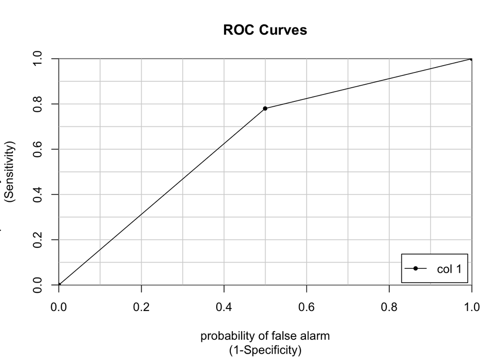

```
##              [,1]
## 0 vs. 1 0.6402427
```

```r
#Plot the ROC curveCalculate the AUROC
colAUC(probsTest[,2], Final_file_test$Outcome, plotROC=TRUE)
```

Evaluating the Classification Accuracy

```r
#Sensitivity (also called the true positive rate, the recall, or probability of detection in some fields) measures the proportion of actual positives that are correctly identified as such. In our case it is the Conversion as in the test  reference and the prediction.
TruePositive = 39

#A true negative test result is one that does not detect the condition when the condition is absent. In our case it will be no conersion in test reference and prediction file.
TrueNegative = 1031

#a test result which incorrectly indicates that a particular condition or attribute is present. So the test Reference file has not correctly predicted for the non conversion
FalsePositive = 1029

##a test result which incorrectly indicates that a particular condition or attribute is absent. So the test Reference file has not correctly predicted for the conversion
FalseNegative = 11

TruePositiveRate = TruePositive/(TruePositive + FalseNegative)
TruePositiveRate
```

```
## [1] 0.78
```

```r
TrueNegativeRate = TrueNegative/(TrueNegative+FalsePositive)
TrueNegativeRate
```

```
## [1] 0.5004854
```

```r
#Accuracy is not a reliable metric for the real performance of a classifier, because it will yield misleading results if the data set is unbalanced (that is, when the numbers of observations in different classes vary greatly).
Accuracy = (TruePositive+TrueNegative)/(TrueNegative+TruePositive+FalseNegative+FalsePositive)
Accuracy
```

```
## [1] 0.507109
```

The area under the ROC curve is 65%. The true positive rate or the sensitivity at 78% is good which measures the proportion of actual positives or actual conversion in our case that are correctly identified. The true negative rate is 50%. The False positive(=1029) is also high, so the false alarm is high and this may distort the prediction of conversion.

```r
set.seed(1234)
train_data <- createDataPartition(Final_file_01$Outcome, p = .75, list = FALSE)
Final_file_train <- Final_file_01[train_data, ]
Final_file_test <- Final_file_01[-train_data, ]

Final_file_02 <- Final_file_01 %>% mutate(Outcome_C = ifelse(Outcome == 1, "Buy", "No_Buy"))
levels(Final_file_02$Outcome)
```

```r
logist_02 <- train(Outcome_C ~ Test_Variable + Test_Variable * Has_email + Has_State , data = Final_file_02, method = "glm", family = "binomial", metric=cmetric,trControl = trainControl("cv", number = 10, summaryFunction=twoClassSummary, classProbs = TRUE))

logist_02
```

```
## Generalized Linear Model
##
## 8442 samples
##    3 predictor
##    2 classes: 'Buy', 'No_Buy'
##
## No pre-processing
## Resampling: Cross-Validated (10 fold)
## Summary of sample sizes: 7597, 7598, 7598, 7597, 7598, 7598, ...
## Resampling results:
##
##   ROC        Sens  Spec
##   0.7541561  0     1
```

```r
# Model coefficients and confusion matrix on train data
coef(logist_02$finalModel)
```

```
##               (Intercept)             Test_Variable
##                 5.4345126                -1.4257640
##                 Has_email                 Has_State
##                -1.2181435                -0.7233513
## `Test_Variable:Has_email`
##                -0.1211825
```

```r
#install.packages("e1071")
library(e1071)

# Make predictions and clauclate confusionmatrix on Test data
probsTest_02 <- predict(logist_02, type="prob", newdata=Final_file_test )
head(probsTest_02)
```

```
##           Buy    No_Buy
## 1 0.017832336 0.9821677
## 2 0.004344405 0.9956556
## 4 0.017832336 0.9821677
## 6 0.017832336 0.9821677
## 8 0.036075558 0.9639244
## 9 0.004344405 0.9956556
```

```r
#Threshold pf .03
Preds_02 <- factor(ifelse(probsTest_02$Buy > .03, 1, 0) )
Final_file_test$Outcome <- as.factor(Final_file_test$Outcome)
confusionMatrix(Preds_02,  Final_file_test$Outcome)
```

```
## Confusion Matrix and Statistics
##
##           Reference
## Prediction    0    1
##          0 1571   20
##          1  489   30
##
##                Accuracy : 0.7588
##                  95% CI : (0.7399, 0.7769)
##     No Information Rate : 0.9763
##     P-Value [Acc > NIR] : 1
##
##                   Kappa : 0.065
##  Mcnemar's Test P-Value : <2e-16
##
##             Sensitivity : 0.7626
##             Specificity : 0.6000
##          Pos Pred Value : 0.9874
##          Neg Pred Value : 0.0578
##              Prevalence : 0.9763
##          Detection Rate : 0.7445
##    Detection Prevalence : 0.7540
##       Balanced Accuracy : 0.6813
##
##        'Positive' Class : 0
##
```

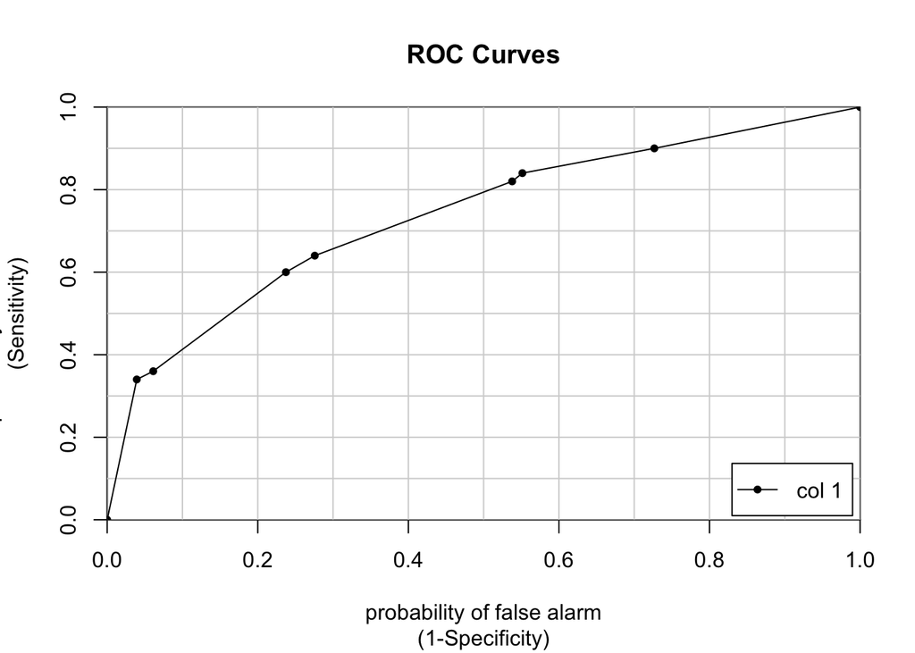

```
##              [,1]
## 0 vs. 1 0.7374272
```

```r
#Plot the ROC curveCalculate the AUROC
colAUC(probsTest_02[,2], Final_file_test$Outcome, plotROC=TRUE)
```

We see that using interaction has improved the ROC curve to 75.41%.

Evalusting the Classification Accuracy

```r
#Sensitivity (also called the true positive rate, the recall, or probability of detection in some fields) measures the proportion of actual positives that are correctly identified as such. In our case it is the Conversion as in the test  reference and the prediction.
TruePositive = 30

#A true negative test result is one that does not detect the condition when the condition is absent. In our case it will be no conersion in test reference and prediction file.
TrueNegative = 1571

#a test result which incorrectly indicates that a particular condition or attribute is present. So the test Reference file has not correctly predicted for the non conversion
FalsePositive = 489

##a test result which incorrectly indicates that a particular condition or attribute is absent. So the test Reference file has not correctly predicted for the conversion
FalseNegative = 20

TruePositiveRate = TruePositive/(TruePositive + FalseNegative)
TruePositiveRate
```

```
## [1] 0.6
```

```r
TrueNegativeRate = TrueNegative/(TrueNegative+FalsePositive)
TrueNegativeRate
```

```
## [1] 0.7626214
```

```r
Accuracy = (TruePositive+TrueNegative)/(TrueNegative+TruePositive+FalseNegative+FalsePositive)
Accuracy
```

```
## [1] 0.7587678
```

### V:Statistical Analysis:Response Times

RQ2: You want now to investigate whether the response time (time to make a purchase after the first contact) is influenced by the retargeting campaign. Make sure you describe carefully how you compute response times (there is no clear answer, so make any sensible assumption).

Q15: Set up an appropriate linear regression model to address the RQ2 above. Make sure to select the appropriate subset of customers. Report output analysis with your interpretation. Can the coefficients be interpreted as causal in this case? Is there evidence of any interactions effect?

```r
Model4 <- lm(Outcome ~ Days_in_Between * Test_Variable + Has_email  + Has_State + Test_Variable * Has_email , data= Final_file_02)
summary(Model4)
```

```
##
## Call:
## lm(formula = Outcome ~ Days_in_Between * Test_Variable + Has_email +
##     Has_State + Test_Variable * Has_email, data = Final_file_02)
##
## Residuals:
##      Min       1Q   Median       3Q      Max
## -0.22454 -0.00030 -0.00015 -0.00007  0.34972
##
## Coefficients:
##                                 Estimate Std. Error  t value Pr(>|t|)
## (Intercept)                    1.257e+00  2.814e-03  446.761   <2e-16 ***
## Days_in_Between               -6.286e-03  1.408e-05 -446.578   <2e-16 ***
## Test_Variable                  5.055e-03  3.121e-03    1.620    0.105
## Has_email                      2.512e-04  6.523e-04    0.385    0.700
## Has_State                     -2.304e-04  2.943e-04   -0.783    0.434
## Days_in_Between:Test_Variable -2.450e-05  1.565e-05   -1.565    0.118
## Test_Variable:Has_email        3.677e-04  8.805e-04    0.418    0.676
## ---
## Signif. codes:  0 '***' 0.001 '**' 0.01 '*' 0.05 '.' 0.1 ' ' 1
##
## Residual standard error: 0.0131 on 8435 degrees of freedom
## Multiple R-squared:  0.9922, Adjusted R-squared:  0.9922
## F-statistic: 1.799e+05 on 6 and 8435 DF,  p-value: < 2.2e-16
```

Anova test

```r
anova(Model1, Model2, Model3, Model4, test = "F")
```

```
## Analysis of Variance Table
##
## Model 1: Outcome ~ Test_Variable
## Model 2: Outcome ~ Test_Variable + Has_email + Has_State
## Model 3: Outcome ~ Test_Variable + Test_Variable * Has_email + Has_State
## Model 4: Outcome ~ Days_in_Between * Test_Variable + Has_email + Has_State +
##     Test_Variable * Has_email
##   Res.Df     RSS Df Sum of Sq        F    Pr(>F)
## 1   8440 185.002
## 2   8438 181.892  2     3.110   9058.8 < 2.2e-16 ***
## 3   8437 180.937  1     0.955   5563.9 < 2.2e-16 ***
## 4   8435   1.448  2   179.490 522888.8 < 2.2e-16 ***
## ---
## Signif. codes:  0 '***' 0.001 '**' 0.01 '*' 0.05 '.' 0.1 ' ' 1
```

Model4 is significant and seems to be the fittest model with the least residual sum of squared errors. We see that there is an improved effect on the outcome for conversion if the Days in between is reduced.

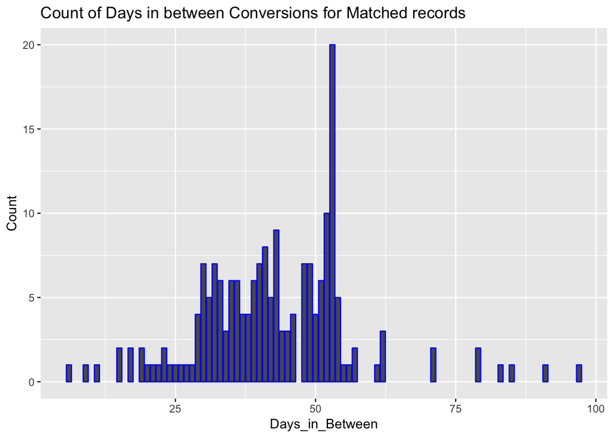

```r
 Final_file_03 <- Final_file_02 %>%  filter(Days_in_Between != 200) %>% group_by(Days_in_Between) %>% count()  %>% arrange(desc(Days_in_Between,n))

Final_file_03 %>% ggplot() + geom_col(aes(x= Days_in_Between, y = n), color = "blue" ) + ylab("Count") + ggtitle("Count of Days in between Conversions for Matched records ")
```

```r
glimpse(Final_file_03)
```

```
## Observations: 51
## Variables: 2
## Groups: Days_in_Between [51]
## $ Days_in_Between <dbl> 97, 91, 85, 83, 79, 71, 62, 61, 57, 56, 55, 54, …
## $ n               <int> 1, 1, 1, 1, 2, 2, 3, 1, 2, 1, 1, 5, 20, 10, 6, 4…
```

The conversion seems to be maximum for days_in_between approximately 20-60 days for matched records.

Q16: Lesson Learned. What would you have done differently in designing the experiment? Any other directions you could have taken with better data? Are there any prescriptive managerial implications out of this study? Please answer briefly.

In this experiment, there was a limitation in matching customers due to missing key information in the abandoned dataset. So we could barely match customers who were randomly placed in a treatment group and retargeted as (treat=1). Hence, if every customer is assigned a unique customer ID and if we had valid values for the various attributes of the customer,it would have been easy in matching and understanding the retargeting effects. With the very limited amount of data that could be matched, we could not draw inference from different States as to which State has the most effective conversion rate.

In the model we see that Days in between has a negative effect on the outcome of conversion and is significant. The larger the number of days between the actual call and the reservation call, the less will be the probability to actually make a reservation. The R2 has also significantly increasesd making this a very good model fit.

So the recommendation from the fit model is that retargeting does help in conversion. Customers should be retargetted before a certain time to achieve maximum probablity of conversion.